# R Notebook

# Estimating correlations adjusted for group membership

`https://www.pipinghotdata.com/posts/2021-10-11-estimating-correlations-adjusted-for-group-membership/`

```r
library(tidyverse)
library(broom)
library(lme4)
library(performance)
library(gt)
library(gtExtras)
library(palmerpenguins)
```

```r
theme_shannon <- function(){
  # theme minimal creates white background and removes ticks on axes ----
  theme_minimal() +
  theme(
    # removes grid lines from plot ----
    panel.grid = element_blank(),
    # moves legend to top instead of side ----
    legend.position = "top",
    # removes title from legend, often superfluous ----
    legend.title = element_blank(),
    # creates the light gray box around the plot ----
    panel.background = element_rect(color = "#F2F2F2"),
    # creates the gray background boxes for faceting labels ----
    strip.background = element_rect(
      color = "#F2F2F2",
      fill = "#F2F2F2"
    ),
    # if using facet grid, this rotates the y text to be more readable ----
    strip.text.y = element_text(angle = 0),
    # this produces a fully left justified title ----
    plot.title.position = "plot"
  )
}
```

A less obvious way the independence observation can be violated is from what Isabella Ghement refers to as a random grouping factor.

`https://twitter.com/IsabellaGhement/status/1443773295426359298`

## Simpson’s paradox: a Palmer penguins example

For initial data preparation, I am retaining the relevant variables, removing missing observations, and creating a duplicate of the species variable for point colors and faceting later.

```r
dat_penguins <- penguins %>%
  dplyr::select(species, bill_depth_mm, body_mass_g) %>%
  # duplicate species variable for coloring & grouping ---
  mutate(species_category = species) %>%
  drop_na()

# species colors used in the palmerpenguins readme ----
colors_penguins <- c(
  "Adelie" = "darkorange",
  "Chinstrap" = "purple",
  "Gentoo" = "cyan4"
  )
```

Let’s examine the correlations between bill_depth_mm and body_mass_g for the three penguin species individually, as well as across all species.

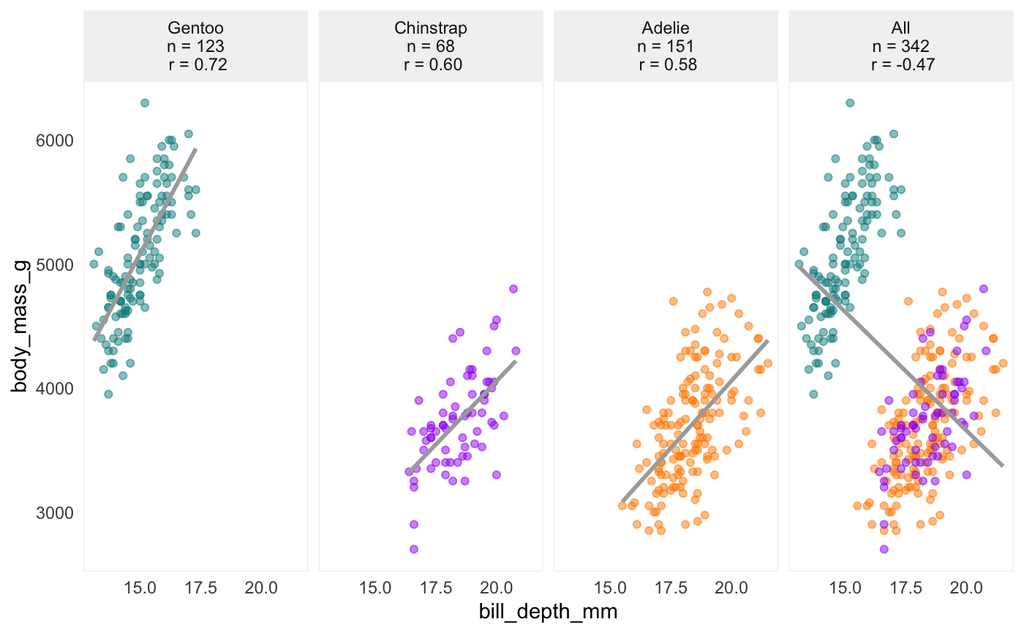

```r
dat_penguins %>%
  # add stack for all species to be analyzed together ----
  bind_rows(dat_penguins %>% mutate(species_category = "All")) %>%
  # now examine by 3 species plus all ----
  group_by(species_category) %>%
  nest() %>%
  # within each group, compute base n and correlation ----
  mutate(
    base_n = map_int(data, nrow),
    corr = map(data, ~ cor.test(x = .x$bill_depth_mm, y = .x$body_mass_g) %>% broom::tidy())
    ) %>%
  ungroup() %>%
  # bring results back to raw data ----
  unnest(c(data, corr)) %>%
  mutate(
    # create ordered facet label for plotting ----
    species_category = fct_relevel(species_category, "Gentoo", "Chinstrap", "Adelie", "All"),
    corr_label =  glue::glue("{species_category}\nn = {base_n}\n r = {scales::number(estimate, 0.01)}"),
    corr_label = fct_reorder(as.character(corr_label), as.numeric(species_category))
   ) %>%
  ggplot(aes(
    x = bill_depth_mm,
    y = body_mass_g
    )) +
    geom_point(aes(color = species), alpha = 0.5, show.legend = FALSE) +
    geom_smooth(method = "lm", color = "darkgray", se = FALSE) +
    facet_wrap(. ~ corr_label, ncol = 4) +
    scale_color_manual(values = colors_penguins) +
    theme_shannon()
```

Here we see that within species the correlations between `bill_depth_mm` and `body_mass_g` are `0.72`, `0.60`, and `0.58`. Yet when we look at the correlation across all species, we have a nonsensical estimate of `-0.47`, which is a classical presentation of Simpson’s paradox.

Getting a reasonable estimate of the correlation between `bill_depth_mm` and `body_mass_g` across all three species requires a bit more work.

To estimate a correlation that adjusts for species, we can implement a `linear mixed model`, also frequently referred to as a `multilevel model`, which

> “allow us to create models for situations where the observations are not independent of one another” as stated in Beyond Multiple Linear Regression: Applied Generalized Linear Models and Multilevel Models in R by Paul Roback and Julie Leger.

In this approach, we model the dependent variable of `body_mass_g` with a **fixed effect** for `bill_depth_mm` (what we want to draw inferences about) and a **random effect** for `species` (which can be thought of as a sample from a larger population of species that we are not interested in drawing specific inferences about).

The correlation estimate adjusting for **species group membership** is the sign of the `bill_depth_mm` coefficient multiplied by the square root of the variance explained at the different `species` levels. Here, I use the `r2_nakagawa()` function from the `performance` package to extract the relevant $R^{2}$ value.

```r
# estimate mixed model ----
mixed_model <- lme4::lmer(body_mass_g ~ bill_depth_mm + (1 | species), dat_penguins)

# retrieve sign of coefficient ----
coef_sign <- mixed_model %>%
  broom.mixed::tidy() %>%
  filter(term == "bill_depth_mm") %>%
  pull(estimate) %>%
  sign()

# retrieve r2 measure ----
r2_by_group <- performance::r2_nakagawa(mixed_model, by_group = TRUE)$R2[1]

# compute adjusted correlation ----
adj_corr <- coef_sign * sqrt(r2_by_group)

# print result ----
adj_corr
```

[output not shown]

# Multiple features: spotify songs example

```r
# import data ----
dat_raw <- readr::read_csv('https://raw.githubusercontent.com/rfordatascience/tidytuesday/master/data/2020/2020-01-21/spotify_songs.csv')
```

To reduce the scope and simplify, I am going to examine a reduced set of variables from `pop`, `rock`, or `rap` songs in 2019. Our goal is to understand which of `energy`, `speechiness`, `acousticness`, `instrumentalness`, `liveness`, and `valence` have the strongest association with `danceability.`

```r
# initial data prep ----
dat <- dat_raw %>%
  mutate(year = str_sub(track_album_release_date, start = 1, end = 4) %>% as.numeric) %>%
  filter(playlist_genre %in% c("pop", "rock", "rap")) %>%
  filter(year == 2019) %>%
  dplyr::select(track_id, playlist_genre, danceability, energy, speechiness, acousticness, instrumentalness, liveness, valence) %>%
  # create an additional variable for genre to be used later ----
  mutate(music_category = playlist_genre)

dat
```

[output not shown]

[`https://github.com/rfordatascience/tidytuesday/tree/master/data/2020/2020-01-21`](https://github.com/rfordatascience/tidytuesday/tree/master/data/2020/2020-01-21)

```r
# create stacked data for analysis ----
dat_stacked <- dat %>%
  # add in all level for across all genres ----
  bind_rows(dat %>% mutate(music_category = "all")) %>%
  dplyr::select(
    track_id, music_category, playlist_genre, danceability, energy,
    speechiness, acousticness, instrumentalness, liveness, valence
  ) %>%
  # convert to long format for plotting and analysis ----
  pivot_longer(
    -c(track_id, music_category, playlist_genre, danceability),
    names_to = "feature",
    values_to = "value"
  ) %>%
  mutate(
    music_category = fct_relevel(music_category, "pop", "rock", "rap", "all"),
    # reordered by a sneak peak at results below ----
    feature = fct_relevel(feature, "valence", "speechiness", "energy", "acousticness", "liveness", "instrumentalness")
  )
```

## Visual exploration

```r
# colors for playlist genre ----
colors_genre <- c(
  "pop" = "#E76F51",
  "rock" = "#264653",
  "rap" = "#E9C46A"
)

dat_stacked %>%
  ggplot(aes(x = value, y = danceability)) +
  geom_point(aes(color = playlist_genre), alpha = 0.2, show.legend = FALSE) +
  facet_grid(feature ~ music_category, scales = "free") +
  scale_color_manual(values = colors_genre) +
  theme_shannon()
```

[output not shown]

### Correlation computations

First, we compute correlations for the three genres individually and the unadjusted correlations across all genres together.

```r
results_1 <- dat_stacked %>%
  group_by(music_category, feature) %>%
  nest() %>%
  mutate(
    corr = map(data, ~ cor.test(x = .x$value, y = .x$danceability) %>% broom::tidy())
    ) %>%
  ungroup() %>%
  unnest(c(corr)) %>%
  dplyr::select(music_category, feature, corr = estimate)
```

Next, we compute the adjusted correlations across all genres together through the linear mixed model. To facilitate this computation, here is a quick function.

```r
compute_adj_corr <- function(data, var_dep, var_ind, var_group){

  mixed_formula <- glue::glue("{var_dep} ~ {var_ind} + (1 | {var_group})")

  mixed_model <- lme4::lmer(mixed_formula, data)

  coef_sign <- mixed_model %>%
    broom.mixed::tidy() %>%
    filter(term == var_ind) %>%
    pull(estimate) %>%
    sign()

 r2_by_group <- performance::r2_nakagawa(mixed_model, by_group = TRUE)$R2[1]

 adj_corr <- coef_sign * sqrt(r2_by_group)

 return(adj_corr)
}
```

Now we compute the adjusted correlations.

```r
results_2 <- dat_stacked %>%
  filter(music_category == "all") %>%
  group_by(feature) %>%
  nest() %>%
  mutate(
    corr = map_dbl(
      data,
      compute_adj_corr,
      var_dep = "danceability",
      var_ind = "value",
      var_group = "playlist_genre"
    )
  ) %>%
  mutate(music_category = "adjusted") %>%
  dplyr::select(music_category, feature, corr)
```

Finally, we combine both sets of results into a single data set for presentation.

```r
results_all <- results_1 %>%
  bind_rows(results_2) %>%
  pivot_wider(
    names_from = "music_category",
    values_from = "corr"
    ) %>%
  mutate_if(is.numeric, round, 2) %>%
  arrange(desc(adjusted)) %>%
  rename(unadjusted = all)
```

### Results

```r
results_all %>%
  gt::gt() %>%
  gt::tab_header(
    title = "Correlations with danceability"
  ) %>%
  gt::tab_spanner(
    label = "Genres",
    columns = c(pop, rap, rock)
  ) %>%
  gt::tab_spanner(
    label = "All",
    columns = c(unadjusted, adjusted)
  ) %>%
  gt::cols_align(
    align = "left",
    columns = feature
  ) %>%
  gtExtras::gt_hulk_col_numeric(pop:adjusted)
```

[output not shown]

### Discussion

Correlations are used by researchers of all backgrounds and expertise due to their relatively straightforward computation and interpretation. When the distributions of dependent and independent variables are similar across subgroups, the unadjusted simple correlation estimates are likely to be similar to the more complex adjusted correlation estimates; however, when distributions vary by subgroups, simple correlation estimates across subgroups could be incorrect and misleading. A primary defense to guard against this is to plot your data - this can help you to identify grouping effects or when relationships are non-linear. In addition, it should be carefully considered if the relationships across groups are truly of more interest than relationships within groups, as across group results can obscure potentially interesting within group findings.